# Risk Factor Analysis

## Outcome Variable

**Outcome Variable:** ever_stunted

## Predictor Variables

**Intervention Variable:** nhh

**Adjustment Set:**

- arm
- W_mage
- meducyrs
- feducyrs
- hhwealth_quart
- W_mhtcm
- W_mwtkg
- W_mbmi
- W_nrooms
- impfloor
- impsan
- safeh20
- delta_W_mage
- delta_meducyrs
- delta_feducyrs
- delta_hhwealth_quart
- delta_W_mhtcm
- delta_W_mwtkg
- delta_W_mbmi
- delta_W_nrooms
- delta_impfloor
- delta_impsan
- delta_safeh20

## Stratifying Variables

The analysis was stratified on these variable(s):

- agecat
- studyid
- country

## Data Summary

| agecat | studyid | country | nhh | ever_stunted | n_cell | n |
| --- | --- | --- | --- | --- | --- | --- |
| 0-24 months | IRC | INDIA | 3 or less | 0 | 25 | 410 |
| 0-24 months | IRC | INDIA | 3 or less | 1 | 33 | 410 |
| 0-24 months | IRC | INDIA | 4-5 | 0 | 52 | 410 |
| 0-24 months | IRC | INDIA | 4-5 | 1 | 106 | 410 |
| 0-24 months | IRC | INDIA | 6-7 | 0 | 41 | 410 |
| 0-24 months | IRC | INDIA | 6-7 | 1 | 66 | 410 |
| 0-24 months | IRC | INDIA | 8+ | 0 | 29 | 410 |
| 0-24 months | IRC | INDIA | 8+ | 1 | 58 | 410 |
| 0-24 months | LCNI-5 | MALAWI | 3 or less | 0 | 85 | 817 |
| 0-24 months | LCNI-5 | MALAWI | 3 or less | 1 | 140 | 817 |
| 0-24 months | LCNI-5 | MALAWI | 4-5 | 0 | 122 | 817 |
| 0-24 months | LCNI-5 | MALAWI | 4-5 | 1 | 218 | 817 |
| 0-24 months | LCNI-5 | MALAWI | 6-7 | 0 | 61 | 817 |
| 0-24 months | LCNI-5 | MALAWI | 6-7 | 1 | 121 | 817 |
| 0-24 months | LCNI-5 | MALAWI | 8+ | 0 | 28 | 817 |
| 0-24 months | LCNI-5 | MALAWI | 8+ | 1 | 42 | 817 |
| 0-24 months | NIH-Birth | BANGLADESH | 3 or less | 0 | 47 | 629 |
| 0-24 months | NIH-Birth | BANGLADESH | 3 or less | 1 | 70 | 629 |
| 0-24 months | NIH-Birth | BANGLADESH | 4-5 | 0 | 77 | 629 |
| 0-24 months | NIH-Birth | BANGLADESH | 4-5 | 1 | 187 | 629 |
| 0-24 months | NIH-Birth | BANGLADESH | 6-7 | 0 | 42 | 629 |
| 0-24 months | NIH-Birth | BANGLADESH | 6-7 | 1 | 100 | 629 |
| 0-24 months | NIH-Birth | BANGLADESH | 8+ | 0 | 45 | 629 |
| 0-24 months | NIH-Birth | BANGLADESH | 8+ | 1 | 61 | 629 |
| 0-24 months | NIH-Crypto | BANGLADESH | 3 or less | 0 | 60 | 758 |
| 0-24 months | NIH-Crypto | BANGLADESH | 3 or less | 1 | 54 | 758 |
| 0-24 months | NIH-Crypto | BANGLADESH | 4-5 | 0 | 171 | 758 |
| 0-24 months | NIH-Crypto | BANGLADESH | 4-5 | 1 | 171 | 758 |
| 0-24 months | NIH-Crypto | BANGLADESH | 6-7 | 0 | 99 | 758 |
| 0-24 months | NIH-Crypto | BANGLADESH | 6-7 | 1 | 79 | 758 |

[output cut: 114 more lines]

The following strata were considered:

- agecat: 0-24 months, studyid: IRC, country: INDIA
- agecat: 0-24 months, studyid: LCNI-5, country: MALAWI
- agecat: 0-24 months, studyid: NIH-Birth, country: BANGLADESH
- agecat: 0-24 months, studyid: NIH-Crypto, country: BANGLADESH
- agecat: 0-24 months, studyid: PROVIDE, country: BANGLADESH
- agecat: 0-24 months, studyid: SAS-FoodSuppl, country: INDIA
- agecat: 0-6 months, studyid: IRC, country: INDIA
- agecat: 0-6 months, studyid: LCNI-5, country: MALAWI
- agecat: 0-6 months, studyid: NIH-Birth, country: BANGLADESH
- agecat: 0-6 months, studyid: NIH-Crypto, country: BANGLADESH
- agecat: 0-6 months, studyid: PROVIDE, country: BANGLADESH
- agecat: 0-6 months, studyid: SAS-FoodSuppl, country: INDIA
- agecat: 6-24 months, studyid: IRC, country: INDIA
- agecat: 6-24 months, studyid: LCNI-5, country: MALAWI
- agecat: 6-24 months, studyid: NIH-Birth, country: BANGLADESH
- agecat: 6-24 months, studyid: NIH-Crypto, country: BANGLADESH
- agecat: 6-24 months, studyid: PROVIDE, country: BANGLADESH
- agecat: 6-24 months, studyid: SAS-FoodSuppl, country: INDIA

### Dropped Strata

Some strata were dropped due to rare outcomes:

- agecat: 0-6 months, studyid: LCNI-5, country: MALAWI

## Methods Detail

We’re interested in the causal parameters $E[Y_a]$ for all values of $a \in \mathcal{A}$. These parameters represent the mean outcome if, possibly contrary to fact, we intervened to set all units to have $A=a$. Under the randomization and positivity assumptions, these are identified by the statistical parameters $\psi_a=E_W[E_{Y|A,W}(Y|A=a,W)]$. In addition, we’re interested in the mean of $Y$, $E[Y]$ under no intervention (the observed mean). We will estimate these parameters by using SuperLearner to fit the relevant likelihood factors – $E_{Y|A,W}(Y|A=a,W)$ and $p(A=a|W)$, and then updating our likelihood fit using a joint TMLE.

For unadjusted analyses ($W=\{\}$), initial likelihoods were estimated using Lrnr_glm to estimate the simple $E(Y|A)$ and Lrnr_mean to estimate $p(A)$. For adjusted analyses, a small library containing Lrnr_glmnet, Lrnr_xgboost, and Lrnr_mean was used.

Having estimated these parameters, we will then use the delta method to estimate relative risks and attributable risks relative to a prespecified baseline level of $A$.

# Results Detail

## Results Plots

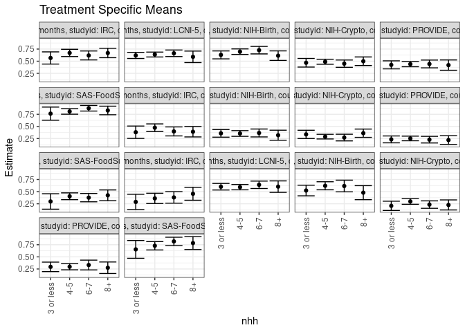

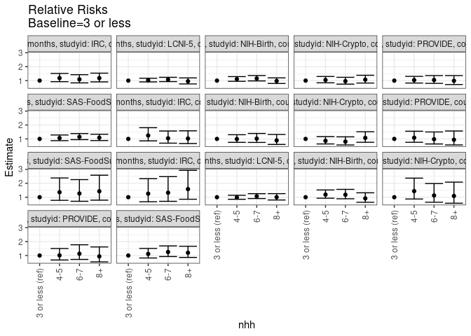

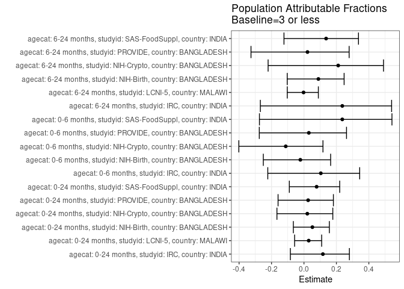

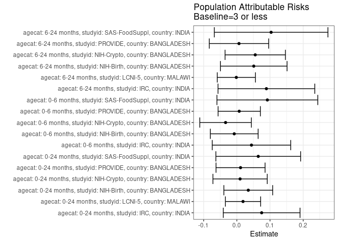

## Results Table

### Parameter: TSM

| agecat | studyid | country | intervention_level | baseline_level | estimate | ci_lower | ci_upper |
| --- | --- | --- | --- | --- | --- | --- | --- |
| 0-24 months | IRC | INDIA | 3 or less | NA | 0.5666289 | 0.4411504 | 0.6921073 |
| 0-24 months | IRC | INDIA | 4-5 | NA | 0.6704829 | 0.5955204 | 0.7454455 |
| 0-24 months | IRC | INDIA | 6-7 | NA | 0.6183828 | 0.5261766 | 0.7105889 |
| 0-24 months | IRC | INDIA | 8+ | NA | 0.6689526 | 0.5724187 | 0.7654864 |
| 0-24 months | LCNI-5 | MALAWI | 3 or less | NA | 0.6190339 | 0.5561513 | 0.6819165 |
| 0-24 months | LCNI-5 | MALAWI | 4-5 | NA | 0.6375703 | 0.5873462 | 0.6877944 |
| 0-24 months | LCNI-5 | MALAWI | 6-7 | NA | 0.6631425 | 0.5956232 | 0.7306618 |
| 0-24 months | LCNI-5 | MALAWI | 8+ | NA | 0.5901953 | 0.4717892 | 0.7086014 |
| 0-24 months | NIH-Birth | BANGLADESH | 3 or less | NA | 0.6299989 | 0.5481151 | 0.7118827 |
| 0-24 months | NIH-Birth | BANGLADESH | 4-5 | NA | 0.6967559 | 0.6399685 | 0.7535433 |
| 0-24 months | NIH-Birth | BANGLADESH | 6-7 | NA | 0.7275873 | 0.6503432 | 0.8048315 |
| 0-24 months | NIH-Birth | BANGLADESH | 8+ | NA | 0.6141729 | 0.5158083 | 0.7125375 |
| 0-24 months | NIH-Crypto | BANGLADESH | 3 or less | NA | 0.4677108 | 0.3787829 | 0.5566386 |
| 0-24 months | NIH-Crypto | BANGLADESH | 4-5 | NA | 0.4888907 | 0.4369059 | 0.5408754 |
| 0-24 months | NIH-Crypto | BANGLADESH | 6-7 | NA | 0.4493326 | 0.3739178 | 0.5247474 |
| 0-24 months | NIH-Crypto | BANGLADESH | 8+ | NA | 0.4992458 | 0.4108375 | 0.5876542 |
| 0-24 months | PROVIDE | BANGLADESH | 3 or less | NA | 0.4244969 | 0.3419108 | 0.5070830 |
| 0-24 months | PROVIDE | BANGLADESH | 4-5 | NA | 0.4401650 | 0.3862583 | 0.4940716 |
| 0-24 months | PROVIDE | BANGLADESH | 6-7 | NA | 0.4431411 | 0.3630435 | 0.5232388 |
| 0-24 months | PROVIDE | BANGLADESH | 8+ | NA | 0.4195919 | 0.3131629 | 0.5260210 |
| 0-24 months | SAS-FoodSuppl | INDIA | 3 or less | NA | 0.7631579 | 0.6278220 | 0.8984938 |
| 0-24 months | SAS-FoodSuppl | INDIA | 4-5 | NA | 0.8087432 | 0.7516931 | 0.8657933 |
| 0-24 months | SAS-FoodSuppl | INDIA | 6-7 | NA | 0.8740157 | 0.8162349 | 0.9317966 |
| 0-24 months | SAS-FoodSuppl | INDIA | 8+ | NA | 0.8285714 | 0.7401768 | 0.9169660 |
| 0-6 months | IRC | INDIA | 3 or less | NA | 0.3802674 | 0.2530002 | 0.5075347 |
| 0-6 months | IRC | INDIA | 4-5 | NA | 0.4734859 | 0.3952531 | 0.5517186 |
| 0-6 months | IRC | INDIA | 6-7 | NA | 0.3969087 | 0.3044147 | 0.4894026 |
| 0-6 months | IRC | INDIA | 8+ | NA | 0.3906760 | 0.2837323 | 0.4976197 |
| 0-6 months | NIH-Birth | BANGLADESH | 3 or less | NA | 0.3575410 | 0.2784638 | 0.4366182 |
| 0-6 months | NIH-Birth | BANGLADESH | 4-5 | NA | 0.3543448 | 0.2956574 | 0.4130322 |
| 0-6 months | NIH-Birth | BANGLADESH | 6-7 | NA | 0.3647682 | 0.2832877 | 0.4462486 |
| 0-6 months | NIH-Birth | BANGLADESH | 8+ | NA | 0.3188804 | 0.2152594 | 0.4225014 |
| 0-6 months | NIH-Crypto | BANGLADESH | 3 or less | NA | 0.3360494 | 0.2513994 | 0.4206994 |
| 0-6 months | NIH-Crypto | BANGLADESH | 4-5 | NA | 0.2895450 | 0.2416719 | 0.3374181 |
| 0-6 months | NIH-Crypto | BANGLADESH | 6-7 | NA | 0.2705642 | 0.2020816 | 0.3390468 |
| 0-6 months | NIH-Crypto | BANGLADESH | 8+ | NA | 0.3603652 | 0.2752229 | 0.4455074 |
| 0-6 months | PROVIDE | BANGLADESH | 3 or less | NA | 0.2327787 | 0.1618489 | 0.3037086 |
| 0-6 months | PROVIDE | BANGLADESH | 4-5 | NA | 0.2524882 | 0.2048346 | 0.3001417 |
| 0-6 months | PROVIDE | BANGLADESH | 6-7 | NA | 0.2273992 | 0.1589474 | 0.2958510 |
| 0-6 months | PROVIDE | BANGLADESH | 8+ | NA | 0.2192992 | 0.1297043 | 0.3088941 |
| 0-6 months | SAS-FoodSuppl | INDIA | 3 or less | NA | 0.2973745 | 0.1384620 | 0.4562870 |
| 0-6 months | SAS-FoodSuppl | INDIA | 4-5 | NA | 0.4043987 | 0.3345817 | 0.4742158 |
| 0-6 months | SAS-FoodSuppl | INDIA | 6-7 | NA | 0.3766053 | 0.2904565 | 0.4627541 |
| 0-6 months | SAS-FoodSuppl | INDIA | 8+ | NA | 0.4243605 | 0.3135303 | 0.5351908 |
| 6-24 months | IRC | INDIA | 3 or less | NA | 0.2879957 | 0.1307717 | 0.4452197 |
| 6-24 months | IRC | INDIA | 4-5 | NA | 0.3608524 | 0.2550125 | 0.4666923 |
| 6-24 months | IRC | INDIA | 6-7 | NA | 0.3807436 | 0.2618236 | 0.4996635 |
| 6-24 months | IRC | INDIA | 8+ | NA | 0.4556541 | 0.3223039 | 0.5890043 |
| 6-24 months | LCNI-5 | MALAWI | 3 or less | NA | 0.6015284 | 0.5334256 | 0.6696311 |
| 6-24 months | LCNI-5 | MALAWI | 4-5 | NA | 0.5926692 | 0.5373549 | 0.6479835 |
| 6-24 months | LCNI-5 | MALAWI | 6-7 | NA | 0.6410712 | 0.5651212 | 0.7170211 |
| 6-24 months | LCNI-5 | MALAWI | 8+ | NA | 0.6032766 | 0.4852590 | 0.7212942 |
| 6-24 months | NIH-Birth | BANGLADESH | 3 or less | NA | 0.5229019 | 0.4135248 | 0.6322790 |
| 6-24 months | NIH-Birth | BANGLADESH | 4-5 | NA | 0.6208222 | 0.5380052 | 0.7036392 |
| 6-24 months | NIH-Birth | BANGLADESH | 6-7 | NA | 0.6160168 | 0.4957229 | 0.7363106 |
| 6-24 months | NIH-Birth | BANGLADESH | 8+ | NA | 0.4789964 | 0.3344127 | 0.6235801 |
| 6-24 months | NIH-Crypto | BANGLADESH | 3 or less | NA | 0.2073420 | 0.1119050 | 0.3027790 |
| 6-24 months | NIH-Crypto | BANGLADESH | 4-5 | NA | 0.2979354 | 0.2391958 | 0.3566750 |
| 6-24 months | NIH-Crypto | BANGLADESH | 6-7 | NA | 0.2331075 | 0.1564161 | 0.3097990 |
| 6-24 months | NIH-Crypto | BANGLADESH | 8+ | NA | 0.2258802 | 0.1226480 | 0.3291123 |
| 6-24 months | PROVIDE | BANGLADESH | 3 or less | NA | 0.2939246 | 0.1960542 | 0.3917951 |
| 6-24 months | PROVIDE | BANGLADESH | 4-5 | NA | 0.2968798 | 0.2325896 | 0.3611700 |
| 6-24 months | PROVIDE | BANGLADESH | 6-7 | NA | 0.3315977 | 0.2310659 | 0.4321295 |
| 6-24 months | PROVIDE | BANGLADESH | 8+ | NA | 0.2754500 | 0.1568204 | 0.3940797 |
| 6-24 months | SAS-FoodSuppl | INDIA | 3 or less | NA | 0.6538462 | 0.4706024 | 0.8370899 |
| 6-24 months | SAS-FoodSuppl | INDIA | 4-5 | NA | 0.7281553 | 0.6420565 | 0.8142542 |
| 6-24 months | SAS-FoodSuppl | INDIA | 6-7 | NA | 0.8181818 | 0.7318558 | 0.9045078 |
| 6-24 months | SAS-FoodSuppl | INDIA | 8+ | NA | 0.7837838 | 0.6508654 | 0.9167021 |

### Parameter: E(Y)

| agecat | studyid | country | intervention_level | baseline_level | estimate | ci_lower | ci_upper |
| --- | --- | --- | --- | --- | --- | --- | --- |
| 0-24 months | IRC | INDIA | NA | NA | 0.6414634 | 0.5949863 | 0.6879405 |
| 0-24 months | LCNI-5 | MALAWI | NA | NA | 0.6376989 | 0.6047193 | 0.6706785 |
| 0-24 months | NIH-Birth | BANGLADESH | NA | NA | 0.6645469 | 0.6276196 | 0.7014742 |
| 0-24 months | NIH-Crypto | BANGLADESH | NA | NA | 0.4775726 | 0.4419904 | 0.5131548 |
| 0-24 months | PROVIDE | BANGLADESH | NA | NA | 0.4357143 | 0.3989556 | 0.4724730 |
| 0-24 months | SAS-FoodSuppl | INDIA | NA | NA | 0.8277512 | 0.7915095 | 0.8639929 |
| 0-6 months | IRC | INDIA | NA | NA | 0.4243902 | 0.3764905 | 0.4722900 |
| 0-6 months | NIH-Birth | BANGLADESH | NA | NA | 0.3497615 | 0.3124631 | 0.3870600 |
| 0-6 months | NIH-Crypto | BANGLADESH | NA | NA | 0.3021108 | 0.2694011 | 0.3348205 |
| 0-6 months | PROVIDE | BANGLADESH | NA | NA | 0.2400000 | 0.2083392 | 0.2716608 |
| 0-6 months | SAS-FoodSuppl | INDIA | NA | NA | 0.3894231 | 0.3425088 | 0.4363374 |
| 6-24 months | IRC | INDIA | NA | NA | 0.3771186 | 0.3151523 | 0.4390850 |
| 6-24 months | LCNI-5 | MALAWI | NA | NA | 0.6000000 | 0.5639396 | 0.6360604 |
| 6-24 months | NIH-Birth | BANGLADESH | NA | NA | 0.5739130 | 0.5216565 | 0.6261696 |
| 6-24 months | NIH-Crypto | BANGLADESH | NA | NA | 0.2628458 | 0.2244546 | 0.3012371 |
| 6-24 months | PROVIDE | BANGLADESH | NA | NA | 0.3004386 | 0.2583143 | 0.3425629 |
| 6-24 months | SAS-FoodSuppl | INDIA | NA | NA | 0.7572016 | 0.7031798 | 0.8112234 |

### Parameter: RR

| agecat | studyid | country | intervention_level | baseline_level | estimate | ci_lower | ci_upper |
| --- | --- | --- | --- | --- | --- | --- | --- |
| 0-24 months | IRC | INDIA | 3 or less | 3 or less | 1.0000000 | 1.0000000 | 1.000000 |
| 0-24 months | IRC | INDIA | 4-5 | 3 or less | 1.1832841 | 0.9231899 | 1.516656 |
| 0-24 months | IRC | INDIA | 6-7 | 3 or less | 1.0913365 | 0.8362569 | 1.424222 |
| 0-24 months | IRC | INDIA | 8+ | 3 or less | 1.1805833 | 0.9074724 | 1.535889 |
| 0-24 months | LCNI-5 | MALAWI | 3 or less | 3 or less | 1.0000000 | 1.0000000 | 1.000000 |
| 0-24 months | LCNI-5 | MALAWI | 4-5 | 3 or less | 1.0299441 | 0.9067199 | 1.169915 |
| 0-24 months | LCNI-5 | MALAWI | 6-7 | 3 or less | 1.0712539 | 0.9283819 | 1.236113 |
| 0-24 months | LCNI-5 | MALAWI | 8+ | 3 or less | 0.9534135 | 0.7615161 | 1.193668 |
| 0-24 months | NIH-Birth | BANGLADESH | 3 or less | 3 or less | 1.0000000 | 1.0000000 | 1.000000 |
| 0-24 months | NIH-Birth | BANGLADESH | 4-5 | 3 or less | 1.1059637 | 0.9496039 | 1.288069 |
| 0-24 months | NIH-Birth | BANGLADESH | 6-7 | 3 or less | 1.1549026 | 0.9777972 | 1.364086 |
| 0-24 months | NIH-Birth | BANGLADESH | 8+ | 3 or less | 0.9748793 | 0.7940943 | 1.196822 |
| 0-24 months | NIH-Crypto | BANGLADESH | 3 or less | 3 or less | 1.0000000 | 1.0000000 | 1.000000 |
| 0-24 months | NIH-Crypto | BANGLADESH | 4-5 | 3 or less | 1.0452841 | 0.8425123 | 1.296858 |
| 0-24 months | NIH-Crypto | BANGLADESH | 6-7 | 3 or less | 0.9607061 | 0.7464496 | 1.236462 |
| 0-24 months | NIH-Crypto | BANGLADESH | 8+ | 3 or less | 1.0674243 | 0.8240165 | 1.382733 |
| 0-24 months | PROVIDE | BANGLADESH | 3 or less | 3 or less | 1.0000000 | 1.0000000 | 1.000000 |
| 0-24 months | PROVIDE | BANGLADESH | 4-5 | 3 or less | 1.0369098 | 0.8246775 | 1.303760 |
| 0-24 months | PROVIDE | BANGLADESH | 6-7 | 3 or less | 1.0439208 | 0.8008459 | 1.360774 |
| 0-24 months | PROVIDE | BANGLADESH | 8+ | 3 or less | 0.9884452 | 0.7181798 | 1.360417 |
| 0-24 months | SAS-FoodSuppl | INDIA | 3 or less | 3 or less | 1.0000000 | 1.0000000 | 1.000000 |
| 0-24 months | SAS-FoodSuppl | INDIA | 4-5 | 3 or less | 1.0597324 | 0.8756092 | 1.282573 |
| 0-24 months | SAS-FoodSuppl | INDIA | 6-7 | 3 or less | 1.1452620 | 0.9477874 | 1.383881 |
| 0-24 months | SAS-FoodSuppl | INDIA | 8+ | 3 or less | 1.0857143 | 0.8827484 | 1.335347 |
| 0-6 months | IRC | INDIA | 3 or less | 3 or less | 1.0000000 | 1.0000000 | 1.000000 |
| 0-6 months | IRC | INDIA | 4-5 | 3 or less | 1.2451391 | 0.8581960 | 1.806547 |
| 0-6 months | IRC | INDIA | 6-7 | 3 or less | 1.0437619 | 0.6944523 | 1.568774 |
| 0-6 months | IRC | INDIA | 8+ | 3 or less | 1.0273716 | 0.6670689 | 1.582284 |
| 0-6 months | NIH-Birth | BANGLADESH | 3 or less | 3 or less | 1.0000000 | 1.0000000 | 1.000000 |
| 0-6 months | NIH-Birth | BANGLADESH | 4-5 | 3 or less | 0.9910607 | 0.7537776 | 1.303039 |
| 0-6 months | NIH-Birth | BANGLADESH | 6-7 | 3 or less | 1.0202135 | 0.7479826 | 1.391524 |
| 0-6 months | NIH-Birth | BANGLADESH | 8+ | 3 or less | 0.8918710 | 0.6029724 | 1.319188 |
| 0-6 months | NIH-Crypto | BANGLADESH | 3 or less | 3 or less | 1.0000000 | 1.0000000 | 1.000000 |
| 0-6 months | NIH-Crypto | BANGLADESH | 4-5 | 3 or less | 0.8616145 | 0.6384282 | 1.162824 |
| 0-6 months | NIH-Crypto | BANGLADESH | 6-7 | 3 or less | 0.8051322 | 0.5636669 | 1.150037 |
| 0-6 months | NIH-Crypto | BANGLADESH | 8+ | 3 or less | 1.0723577 | 0.7596043 | 1.513882 |
| 0-6 months | PROVIDE | BANGLADESH | 3 or less | 3 or less | 1.0000000 | 1.0000000 | 1.000000 |
| 0-6 months | PROVIDE | BANGLADESH | 4-5 | 3 or less | 1.0846702 | 0.7580997 | 1.551919 |
| 0-6 months | PROVIDE | BANGLADESH | 6-7 | 3 or less | 0.9768899 | 0.6365974 | 1.499085 |
| 0-6 months | PROVIDE | BANGLADESH | 8+ | 3 or less | 0.9420929 | 0.5657640 | 1.568744 |
| 0-6 months | SAS-FoodSuppl | INDIA | 3 or less | 3 or less | 1.0000000 | 1.0000000 | 1.000000 |
| 0-6 months | SAS-FoodSuppl | INDIA | 4-5 | 3 or less | 1.3598971 | 0.7763244 | 2.382149 |
| 0-6 months | SAS-FoodSuppl | INDIA | 6-7 | 3 or less | 1.2664343 | 0.7079453 | 2.265508 |
| 0-6 months | SAS-FoodSuppl | INDIA | 8+ | 3 or less | 1.4270239 | 0.7887495 | 2.581805 |
| 6-24 months | IRC | INDIA | 3 or less | 3 or less | 1.0000000 | 1.0000000 | 1.000000 |
| 6-24 months | IRC | INDIA | 4-5 | 3 or less | 1.2529784 | 0.6736367 | 2.330566 |
| 6-24 months | IRC | INDIA | 6-7 | 3 or less | 1.3220459 | 0.7046118 | 2.480522 |
| 6-24 months | IRC | INDIA | 8+ | 3 or less | 1.5821558 | 0.8530057 | 2.934584 |
| 6-24 months | LCNI-5 | MALAWI | 3 or less | 3 or less | 1.0000000 | 1.0000000 | 1.000000 |
| 6-24 months | LCNI-5 | MALAWI | 4-5 | 3 or less | 0.9852722 | 0.8521548 | 1.139184 |
| 6-24 months | LCNI-5 | MALAWI | 6-7 | 3 or less | 1.0657372 | 0.9049054 | 1.255154 |
| 6-24 months | LCNI-5 | MALAWI | 8+ | 3 or less | 1.0029063 | 0.8007443 | 1.256108 |
| 6-24 months | NIH-Birth | BANGLADESH | 3 or less | 3 or less | 1.0000000 | 1.0000000 | 1.000000 |
| 6-24 months | NIH-Birth | BANGLADESH | 4-5 | 3 or less | 1.1872631 | 0.9272706 | 1.520154 |
| 6-24 months | NIH-Birth | BANGLADESH | 6-7 | 3 or less | 1.1780732 | 0.8870384 | 1.564596 |
| 6-24 months | NIH-Birth | BANGLADESH | 8+ | 3 or less | 0.9160348 | 0.6363177 | 1.318712 |
| 6-24 months | NIH-Crypto | BANGLADESH | 3 or less | 3 or less | 1.0000000 | 1.0000000 | 1.000000 |
| 6-24 months | NIH-Crypto | BANGLADESH | 4-5 | 3 or less | 1.4369275 | 0.8709058 | 2.370820 |
| 6-24 months | NIH-Crypto | BANGLADESH | 6-7 | 3 or less | 1.1242659 | 0.6380814 | 1.980897 |
| 6-24 months | NIH-Crypto | BANGLADESH | 8+ | 3 or less | 1.0894088 | 0.5692728 | 2.084785 |
| 6-24 months | PROVIDE | BANGLADESH | 3 or less | 3 or less | 1.0000000 | 1.0000000 | 1.000000 |
| 6-24 months | PROVIDE | BANGLADESH | 4-5 | 3 or less | 1.0100543 | 0.6788799 | 1.502784 |
| 6-24 months | PROVIDE | BANGLADESH | 6-7 | 3 or less | 1.1281725 | 0.7190619 | 1.770047 |
| 6-24 months | PROVIDE | BANGLADESH | 8+ | 3 or less | 0.9371451 | 0.5436647 | 1.615409 |
| 6-24 months | SAS-FoodSuppl | INDIA | 3 or less | 3 or less | 1.0000000 | 1.0000000 | 1.000000 |
| 6-24 months | SAS-FoodSuppl | INDIA | 4-5 | 3 or less | 1.1136493 | 0.8215720 | 1.509563 |
| 6-24 months | SAS-FoodSuppl | INDIA | 6-7 | 3 or less | 1.2513369 | 0.9275155 | 1.688213 |
| 6-24 months | SAS-FoodSuppl | INDIA | 8+ | 3 or less | 1.1987281 | 0.8638907 | 1.663346 |

### Parameter: PAR

| agecat | studyid | country | intervention_level | baseline_level | estimate | ci_lower | ci_upper |
| --- | --- | --- | --- | --- | --- | --- | --- |
| 0-24 months | IRC | INDIA | 3 or less | NA | 0.0748346 | -0.0408413 | 0.1905104 |
| 0-24 months | LCNI-5 | MALAWI | 3 or less | NA | 0.0186650 | -0.0344369 | 0.0717669 |
| 0-24 months | NIH-Birth | BANGLADESH | 3 or less | NA | 0.0345480 | -0.0390354 | 0.1081314 |
| 0-24 months | NIH-Crypto | BANGLADESH | 3 or less | NA | 0.0098618 | -0.0719761 | 0.0916996 |
| 0-24 months | PROVIDE | BANGLADESH | 3 or less | NA | 0.0112174 | -0.0627071 | 0.0851419 |
| 0-24 months | SAS-FoodSuppl | INDIA | 3 or less | NA | 0.0645933 | -0.0630747 | 0.1922613 |
| 0-6 months | IRC | INDIA | 3 or less | NA | 0.0441228 | -0.0741057 | 0.1623513 |
| 0-6 months | NIH-Birth | BANGLADESH | 3 or less | NA | -0.0077795 | -0.0798101 | 0.0642511 |
| 0-6 months | NIH-Crypto | BANGLADESH | 3 or less | NA | -0.0339386 | -0.1115561 | 0.0436789 |
| 0-6 months | PROVIDE | BANGLADESH | 3 or less | NA | 0.0072213 | -0.0565078 | 0.0709504 |
| 0-6 months | SAS-FoodSuppl | INDIA | 3 or less | NA | 0.0920486 | -0.0598875 | 0.2439846 |
| 6-24 months | IRC | INDIA | 3 or less | NA | 0.0891229 | -0.0566750 | 0.2349209 |
| 6-24 months | LCNI-5 | MALAWI | 3 or less | NA | -0.0015284 | -0.0589699 | 0.0559132 |
| 6-24 months | NIH-Birth | BANGLADESH | 3 or less | NA | 0.0510111 | -0.0493051 | 0.1513273 |
| 6-24 months | NIH-Crypto | BANGLADESH | 3 or less | NA | 0.0555039 | -0.0354535 | 0.1464612 |
| 6-24 months | PROVIDE | BANGLADESH | 3 or less | NA | 0.0065140 | -0.0829960 | 0.0960239 |
| 6-24 months | SAS-FoodSuppl | INDIA | 3 or less | NA | 0.1033555 | -0.0678495 | 0.2745605 |

### Parameter: PAF

| agecat | studyid | country | intervention_level | baseline_level | estimate | ci_lower | ci_upper |
| --- | --- | --- | --- | --- | --- | --- | --- |
| 0-24 months | IRC | INDIA | 3 or less | NA | 0.1166622 | -0.0838343 | 0.2800693 |
| 0-24 months | LCNI-5 | MALAWI | 3 or less | NA | 0.0292693 | -0.0577148 | 0.1091000 |
| 0-24 months | NIH-Birth | BANGLADESH | 3 or less | NA | 0.0519873 | -0.0654642 | 0.1564915 |
| 0-24 months | NIH-Crypto | BANGLADESH | 3 or less | NA | 0.0206498 | -0.1666092 | 0.1778508 |
| 0-24 months | PROVIDE | BANGLADESH | 3 or less | NA | 0.0257448 | -0.1596059 | 0.1814692 |
| 0-24 months | SAS-FoodSuppl | INDIA | 3 or less | NA | 0.0780347 | -0.0902029 | 0.2203102 |
| 0-6 months | IRC | INDIA | 3 or less | NA | 0.1039675 | -0.2230145 | 0.3435285 |
| 0-6 months | NIH-Birth | BANGLADESH | 3 or less | NA | -0.0222422 | -0.2505880 | 0.1644097 |
| 0-6 months | NIH-Crypto | BANGLADESH | 3 or less | NA | -0.1123382 | -0.4014960 | 0.1171604 |
| 0-6 months | PROVIDE | BANGLADESH | 3 or less | NA | 0.0300886 | -0.2753520 | 0.2623777 |
| 0-6 months | SAS-FoodSuppl | INDIA | 3 or less | NA | 0.2363716 | -0.2744637 | 0.5424520 |
| 6-24 months | IRC | INDIA | 3 or less | NA | 0.2363259 | -0.2688683 | 0.5403794 |
| 6-24 months | LCNI-5 | MALAWI | 3 or less | NA | -0.0025473 | -0.1030018 | 0.0887585 |
| 6-24 months | NIH-Birth | BANGLADESH | 3 or less | NA | 0.0888830 | -0.1032522 | 0.2475571 |
| 6-24 months | NIH-Crypto | BANGLADESH | 3 or less | NA | 0.2111651 | -0.2209706 | 0.4903558 |
| 6-24 months | PROVIDE | BANGLADESH | 3 or less | NA | 0.0216815 | -0.3264999 | 0.2784718 |
| 6-24 months | SAS-FoodSuppl | INDIA | 3 or less | NA | 0.1364967 | -0.1231626 | 0.3361264 |